# HW1 and R basic

Transformations  
用log()讓圖更好看!

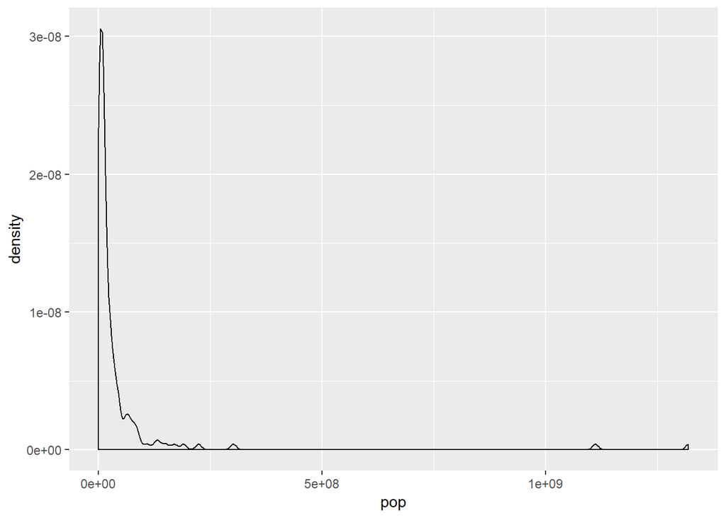

```r
gap2007 %>%
  ggplot(aes(x = pop)) +
  geom_density(alpha=.3)
```

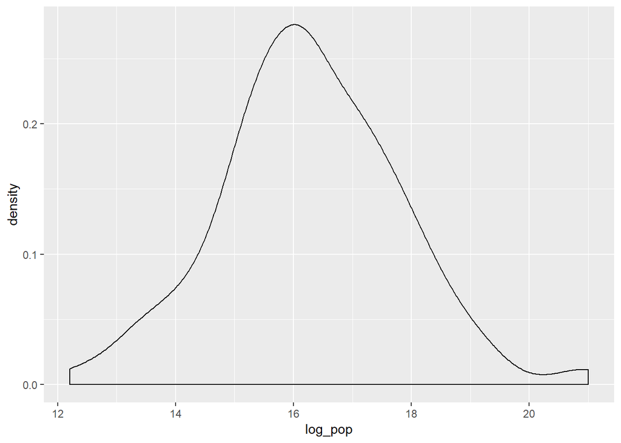

```r
gap2007 <- gap2007 %>%
  mutate(log_pop=log(pop))
gap2007 %>%
  ggplot(aes(x = log_pop)) +
  geom_density(alpha=.3)
```

identify outliers

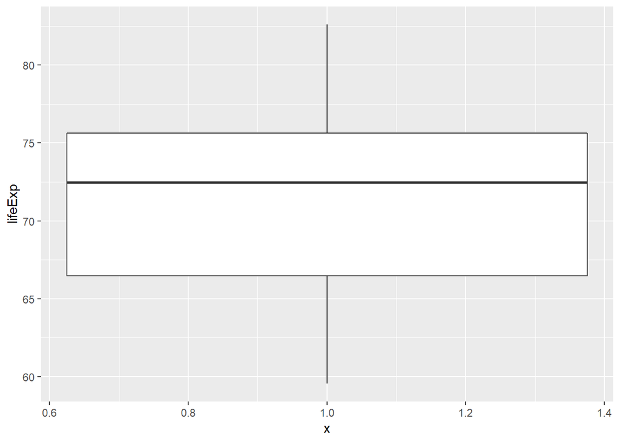

```r
gap_asia <- gap2007 %>%
  filter(continent=="Asia") %>%
  mutate(is_outlier = lifeExp<50)
gap_asia %>%
  filter(!is_outlier) %>%
  ggplot(aes(x = 1, y = lifeExp)) +
  geom_boxplot()
```

## Case Study

以下以email這個data做例子

```r
if(!require(openintro))install.packages("openintro",repos = "http://cran.us.r-project.org")
```

```
## Please visit openintro.org for free statistics materials
```

```r
library(ggplot2)
library(openintro)
library(dplyr)
email %>%
  group_by(spam) %>%
  summarize(median(num_char),
            IQR(num_char))
```

```
## # A tibble: 2 x 3
##    spam `median(num_char)` `IQR(num_char)`
##   <dbl>              <dbl>           <dbl>
## 1     0               6.83           13.6
## 2     1               1.05            2.82
```

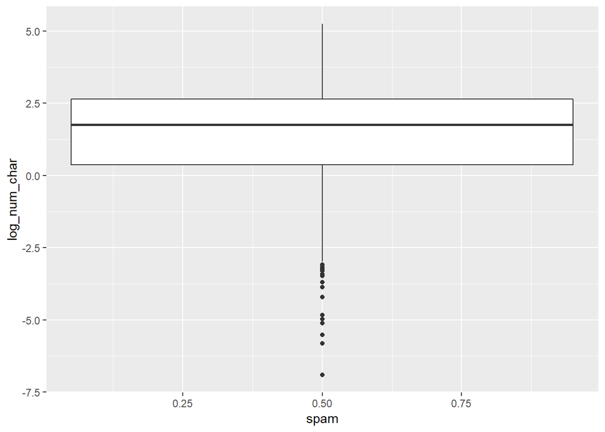

```r
email %>%
  mutate(log_num_char = log(num_char)) %>%
  ggplot(aes(x = spam, y = log_num_char)) +
  geom_boxplot()
```

接下來請注意一個細節  
如果log(0)在r會是個-inf  
這樣會無法畫圖  
所以可以加個.01  
這樣就不會有問題了

```r
email %>%
  group_by(spam) %>%
  summarize(median(exclaim_mess),
            IQR(exclaim_mess))
```

```
## # A tibble: 2 x 3
##    spam `median(exclaim_mess)` `IQR(exclaim_mess)`
##   <dbl>                  <dbl>               <dbl>
## 1     0                      1                   5
## 2     1                      0                   1
```

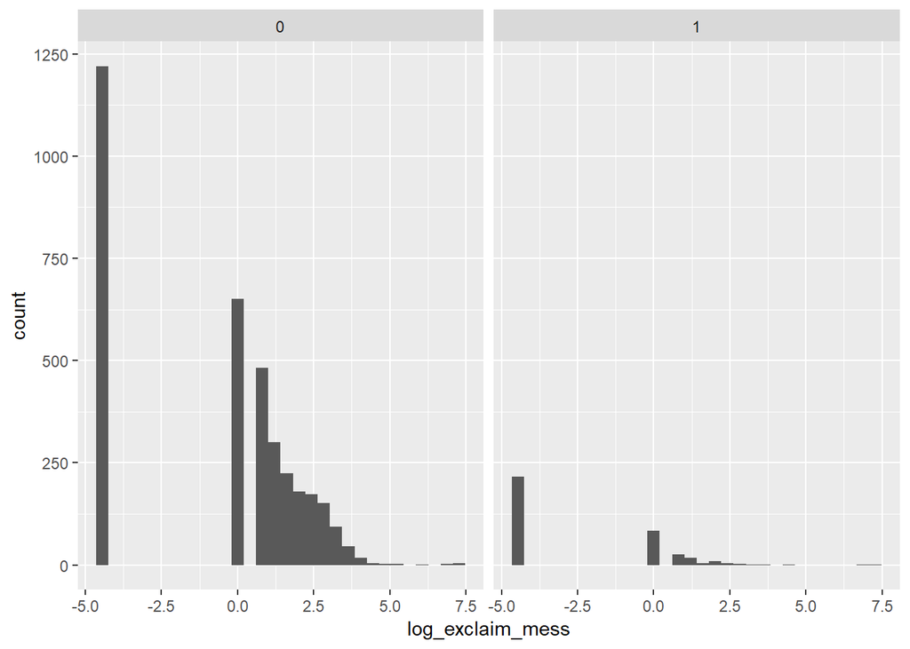

```r
# Create plot for spam and exclaim_mess
email %>%
  mutate(log_exclaim_mess = log(exclaim_mess + .01)) %>%
  ggplot(aes(x = log_exclaim_mess)) +
  geom_histogram() +
  facet_wrap(~ spam)
```

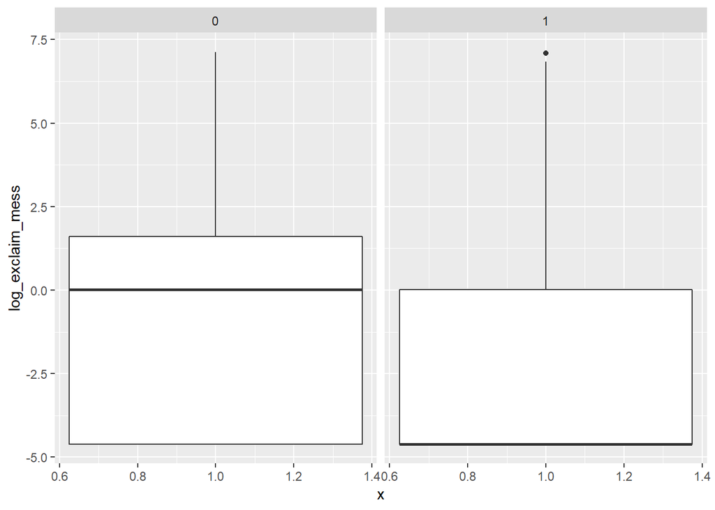

```r
# Alternative plot: side-by-side box plots
email %>%
  mutate(log_exclaim_mess = log(exclaim_mess + .01)) %>%
  ggplot(aes(x = 1, y = log_exclaim_mess)) +
  geom_boxplot() +
  facet_wrap(~ spam)
```

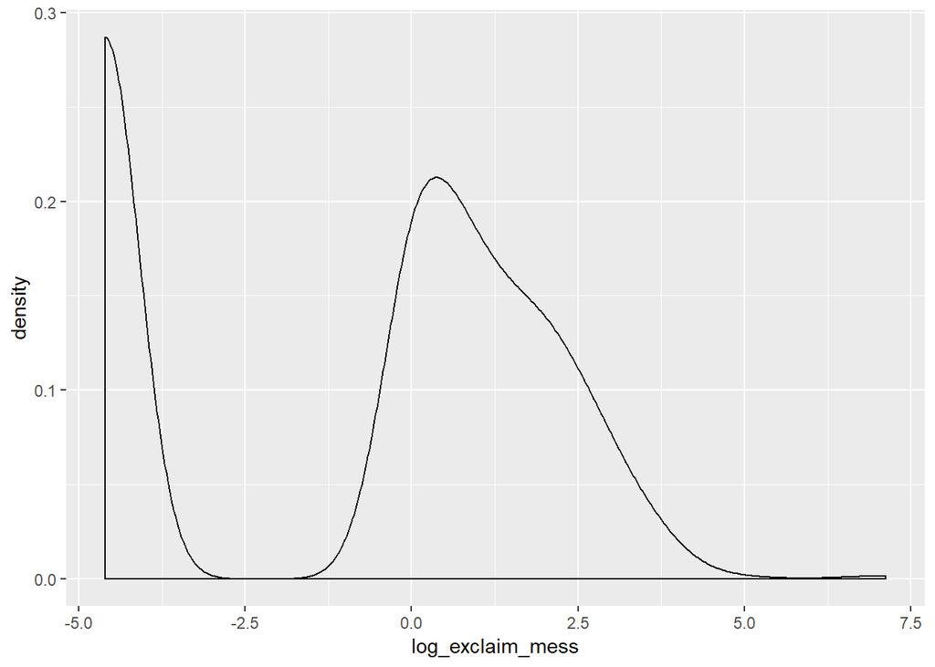

```r
# Alternative plot: Overlaid density plots
email %>%
  mutate(log_exclaim_mess = log(exclaim_mess + .01)) %>%
  ggplot(aes(x = log_exclaim_mess, fill = spam)) +
  geom_density(alpha = 0.3)
```

Check-in 1  
以下程式碼處理屬於image=0和>0的資料

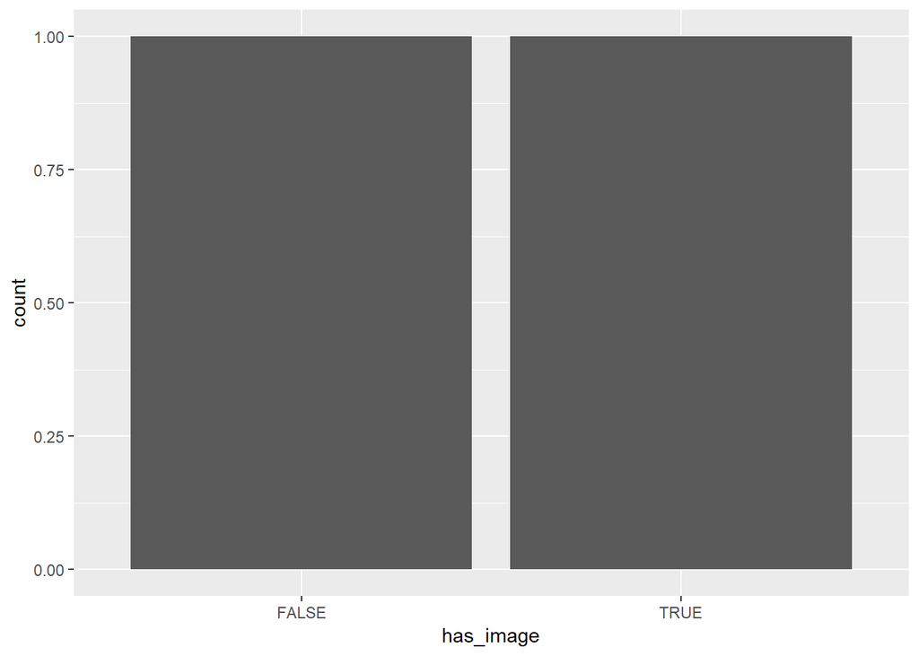

```r
# Create plot of proportion of spam by image
email %>%
  mutate(has_image = image>0) %>%
  ggplot(aes(x =has_image, fill = spam)) +
  geom_bar(position = "fill")
```

Check-in 2

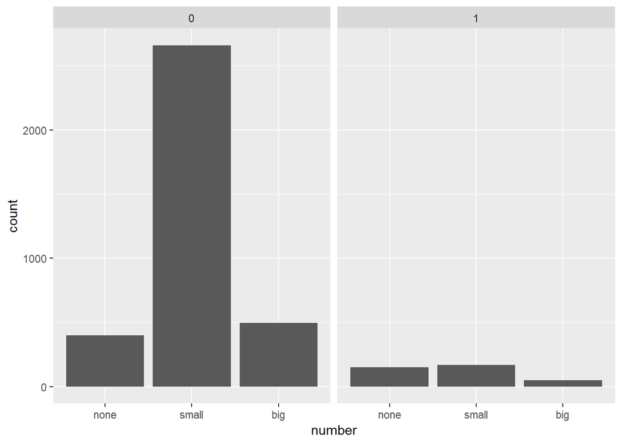

```r
email$number <- factor(email$number, levels = c("none", "small", "big"))
ggplot(email, aes(x = number)) +
  geom_bar() +
  facet_wrap(~ spam)
```

- 回目錄

# Cleaning Data in R

## Introduction and exploring raw data

此大章節以下面三個流程展現:  
1. Exploring raw data  
2. Tidying data  
3. Preparing data for analysis  
以下幾個函數可以讓你在整理前隊整理的資料有初步了解:  
1. class():class of data object  
2. dim():dimensions of data  
3. names():column names  
4. str():preview of data with helpful details  
5. glimpse():better version of str() from dplyr  
6. summary():summary of data  
以下幾個函數讓你先了解一下你的資料內容:  
1. head():view top of dataset  
2. tail():view bottom of dataset  
3. print():view entire dataset(不建議)  
4. hist():view histogram of a single variable  
5. plot():view plot of two variables

## Tidying data

Principles of tidy data  
1. Each observation forms a row, each variable forms a column, and each type of observational unit forms a table  
2. Each value belongs to a variable and an observation  
3. A dataset is a collection of values  
以下三個是錯誤的資料整理例子:  
1. Variables are stored in both rows and columns  
2. Column headers are values, not variable names  
3. A single observational unit is stored in multiple tables  
Introduction to tidyer  
以下介紹gather()和spread()這兩個互相相反又強大的函數  
gather(data,key,value,…)  
data: a data frame  
key: bare name of new key column  
value: bare name of new value column  
…: bare names of columns to gather(or not)  
spread(data,key,value)  
data: a data frame  
key: bare name of column containing keys  
value: bare name of column containing values  
Introduction to tidyr (part 2)  
以下介紹separate()和unite()這兩個互相相反又強大的函數  
separate(data,col,into)  
data: a data frame  
col: bare name of column to separate  
into: character vector(注意) of new column names  
unite(data,col,…)  
data: a data frame  
col:bare name of new column  
…: bare names of columns to unite  
要怎麼分跟怎麼和都用sep=“你想要得符號”  
統整  
1.gather():Gather columns into key-value pairs  
spread():Spread key-value pairs into columns  
separate():Separate one column into multiple  
unite():Unite multiple columns into one

## Preparing data for analysis

type conversions  
有很多種儲存形式，比如character,mumerical,integer,logical,factor以及date  
善用class()來判別你的類型  
善用as.xxx()來改變你資料的類型  
注意!!!用lubridate這個package來把東西改變成date!!!  
lubridate分成y,m,d,h,m,s(年月日時分秒)照著你看到的資料做變化，他會把你看到的資料變成統一規格

```r
if(!require(lubridate))install.packages("lubridate",repos = "http://cran.us.r-project.org")
library(lubridate)
dmy("17 Sep 2015")
```

```
## [1] "2015-09-17"
```

```r
mdy_hm("July 15, 2012 12:56")
```

```
## [1] "2012-07-15 12:56:00 UTC"
```

String manipulation  
tolower()>全部轉小寫  
toupper()>全部轉大寫  
接下來要介紹四格強大函數  
str_trim():trim leading and trailing white space  
str_pad():pad with additional characters  
str_detect():detect a pattern  
str_replace():find and replace a pattern

```r
if(!require(stringr))install.packages("stringr",repos = "http://cran.us.r-project.org")
library(stringr)
str_trim(c("   Filip ", "Nick  ", " Jonathan"))
```

```
## [1] "Filip"    "Nick"     "Jonathan"
```

```r
str_pad(c("23485W", "8823453Q", "994Z"),width=9,side="left",pad="0")
```

```
## [1] "00023485W" "08823453Q" "00000994Z"
```

Missing and special values  
is.na()TRUE代表他是NA資料  
any(is.na())查出他是否有NA資料  
sum(is.na())找出有幾個NA  
summary()也可以看出有幾個NA  
complete.cases()>find rows with no missing values  
df[complete.cases(),]>suvbset data,keeping only complete cases  
na.omit()>another way to remove rows with NAs  
Outliers and obvious errors  
summary()以及hist()這兩個函數使我們容易看見資料明顯的錯誤與偏差  
boxplot()也是個好選擇

## Putting it all together

which(is.na())看出哪幾項是NA

- 回目錄